# 10 Primera Iteración - Modelamiento y Evaluación

## Antes de entrenar un modelo, aprendamos sobre el funcionamiento y la API de scikit-learn

```python
import numpy as np
import pandas as pd
```

Scikit-learn es la librería más usada de Machine Learning tradicional [Ver ranking de Github](https://github.com/showcases/machine-learning). La librería incluye funcionalidades de:

- Preprocesamiento de datos en `sklearn.preprocessing`
- Algoritmos de Machine Learning en `sklearn.linear_model`, `sklearn.svm`, `sklearn.ensemble`, y muchos más.
- Evaluación de modelos en `sklearn.model_selection` y `sklearn.metrics`

Scikit-learn sigue muy de cerca los resultados de la investigación e implementa los resultados más maduros y probados en sus modulos. La [documentación](http://scikit-learn.org/stable/modules/ensemble.html#forests-of-randomized-trees) extensa muestra como la librería es un compendio de conocimiento en Machine Learning llevado a software

Una estructura de datos esencial en scikit-learn es el **Estimator**

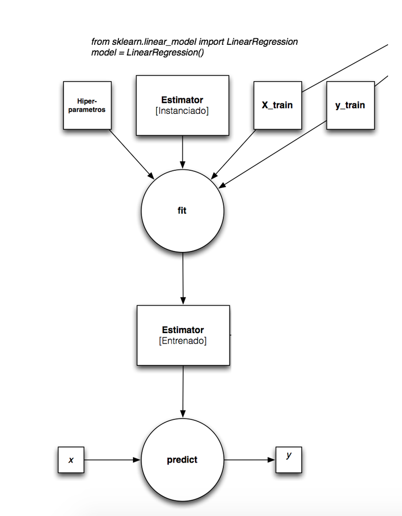

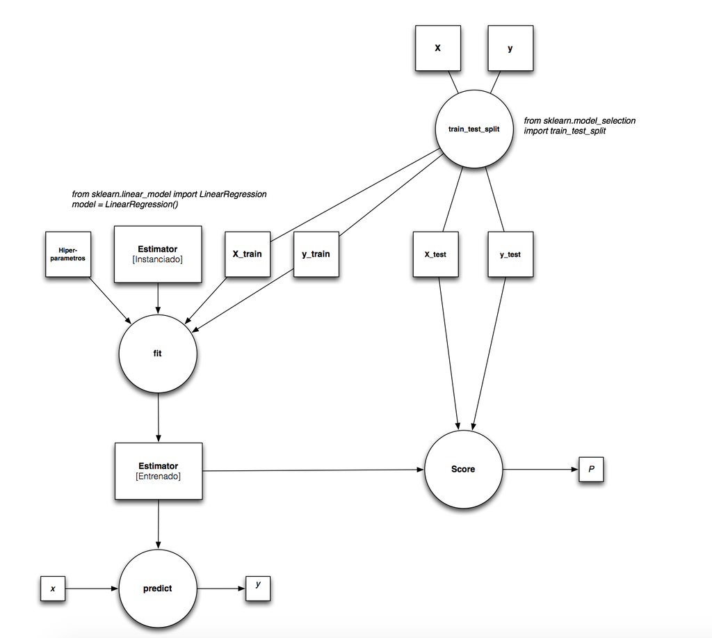

## Implementemos un modelo simple de regresión primero

```python
X = pd.read_csv('../vol/intermediate_results/X.csv')
```

```python
y = X['worldwide_gross']
```

```python
X = X.drop('worldwide_gross',axis=1)
```

```python
from sklearn.model_selection import train_test_split

X_train, X_test, y_train, y_test = train_test_split(X,y,test_size=0.4,random_state=1)
```

```python
print(len(X))
print(len(X_train))
print(len(X_test))
```

```
4104
2462
1642
```

```python
X.head(1)
```

|  | production_budget | title_year | aspect_ratio | duration.1 | cast_total_facebook_likes | budget | imdb_score |
| --- | --- | --- | --- | --- | --- | --- | --- |
| 0 | 425000000.0 | 2009.0 | 1.78 | 178.0 | 4834.0 | 237000000.0 | 7.9 |

```python
from sklearn.linear_model import Lasso

model = Lasso()
```

```python
model.fit(X_train,y_train)
```

```
Lasso(alpha=1.0, copy_X=True, fit_intercept=True, max_iter=1000,
   normalize=False, positive=False, precompute=False, random_state=None,
   selection='cyclic', tol=0.0001, warm_start=False)
```

```python
predicted = model.predict(X_test)
```

```python
predicted.shape
```

```
(1642,)
```

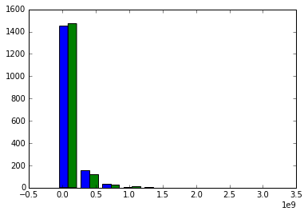

```python
import matplotlib.pyplot as plt
%matplotlib inline

plt.hist([predicted,y_test]);
```

## Evaluemos de forma más fina el comportamiento de nuestro modelo

Los estimadores y las funciones de sklearn vienen con el máximo de argumentos con valores por defecto que suelen ser las mejores opciones si no tenemos algun conocimiento particular el problema. En este caso particular la función `estimator.score` ya viene con una de las métricas de `sklearn.metrics`, que es la métrica `sklearn.metric.r2_score`

El **score R2** de una regresión es una de las formas más comunes de entender su poder predictivo. Este **mientras más cerca de 1 este, mejor es**

Los valores que puede tomar son de -infinito hasta 1. Un score R2 negativo es malo, ya que esto indica que la regresión es peor que si simplemente eligieramos un valor fijo como predicción para todos los puntos, la media.

```python
model.score(X_test,y_test)
```

```
0.6021797062956975
```

Bastante bien para un primer modelo!

Un buen score R2 es importante para una regresión. Pero no lo es todo. De forma general los scores hay que complementarlos con visualizaciones de los datos ya que una métrica no logra siempre encodear todas las caracteristicas de una distribución de probabilidades. Un ejemplo es el siguiente:

[figure not shown]

**Siempre visualiza tus resultados**, aunque tengas un buen score de performance.

```python
residuals = y_test - predicted
```

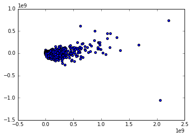

```python
plt.scatter(y_test,residuals)
```

```python
ap_residuals = np.abs(residuals) / y_test
```

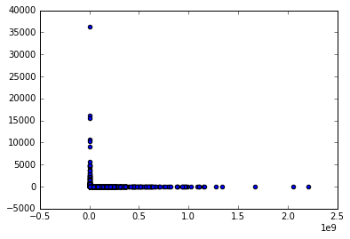

```python
plt.scatter(y_test,ap_residuals)
```

```python
lap_residuals = np.log(ap_residuals)
```

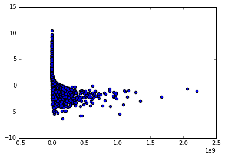

```python
plt.scatter(y_test,lap_residuals)
```

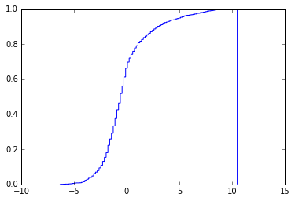

```python
plt.hist(lap_residuals,bins=100, normed=1, histtype='step', cumulative=True);
```

```
array([ 0.13533528,  0.22313016,  0.36787944,  0.60653066,  1.        ])
```

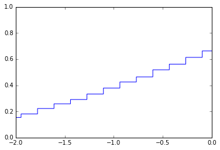

```python
plt.hist(lap_residuals, bins=100, normed=1, histtype='step',cumulative=True);
plt.axis([-2,0,0,1])
np.power(np.exp(1)*np.ones(5),np.linspace(-2,0,5))
```

[figure not shown]

```python
plt.scatter(np.arange(8),model.coef_)
```

```python
X = pd.read_csv('../vol/intermediate_results/X.csv')
```

```python
X = X.drop('gross',axis=1)
```

```python
X = X.drop('worldwide_gross',axis=1)
```

```python
from sklearn.model_selection import train_test_split

X_train, X_test, y_train, y_test = train_test_split(X,y,test_size=0.4)
```

```python
model = Lasso()
model.fit(X_train,y_train)
```

```
Lasso(alpha=1.0, copy_X=True, fit_intercept=True, max_iter=1000,
   normalize=False, positive=False, precompute=False, random_state=None,
   selection='cyclic', tol=0.0001, warm_start=False)
```

```python
model.score(X_test,y_test)
```

```
0.87745681705925049
```

```python
X.columns
```

[output not shown]

```python
for el in zip(list(X.columns),list(model.coef_)):
    print(el)
```

[output not shown]